# notebook

MAF1731 - Microstructure and Trading Systems

Lab 1: Inversión de Capital

B.Eng Financial Engineering

I.F. Mario Abel García Verduzco

Jun 2021 | Repositorio en GitHub: [Link](https://github.com/marioabel96/myst_magv_lab1)

Abstract

# Introducción

El propósito de este laboratorio es responder a la pregunta: **¿Qué estrategia de inversión propondrías si tu trabajo fuera invertir 1 Millón de pesos?** Basados en el “NAFTRAC” exploramos 2 alternativas en este trabajo: - Inversión pasiva. - Inversión activa. Para el primer caso, en nuestra estrategia pasiva exploramos que sucedió durante dos lapsos de tiempo. El primer caso fue en el tiempo Pre-pandemia, que esta comprendido en el lapso: 31-01-2018 a 31-01-2020. Y, nuestro segundo caso fue en el periodo durante la pandemia: 28-02-2020 a 28-02-2021. En el segundo caso, decidimos iniciar el portafolio de acuerdo con el “NAFTRAC” en el primer periodo de tiempo, e ir aplicando un criterio de rebalanceo cada mes. Al Final compararemos nuestros resultados con un cuadro de medidas de atribución al desempeño para descubrir la respuesta a la pregunta planteada.

# Librerías y dependencias

### Python Packages

Para correr este Notebook es necesaria tener instalar las librerías contenidas en requirements.txt:

- pandas>=1.1.0
- numpy>=1.19.1
- jupyter>=1.0.0
- chart_studio>=1.1
- plotly>=4.14
- datetime
- os

```python
from data import *
from functions import *
import pandas as pd
import numpy as np
from os import listdir, path
from os.path import isfile, join
import warnings
warnings.filterwarnings('ignore')
# variable para mostrar solo el inicio y el final de un dataframe
pd.DataFrame.less = lambda df, n=10: df.head(n//2).append(df.tail(n//2))
```

### Files Dependencies

Para correr este Notebook también necesitaras las siguientes dependencias:

- files/NAFTRAC_ : Precios históricos NAFTRAC (20180131 - 20210331)
- requirements.txt : librerías

# Descripción de los datos

Dentro de la carpeta "files" tenemos los datos históricos del activo de renta variable ["NAFTRAC"](https://www.blackrock.com/mx/intermediarios/productos/251895/ishares-naftrac-fund). Un ETF que busca resultados de inversión que correspondan al índice S&P/BMV IPC. Utilizamos históricos desde Enero de 2018 hasta Marzo 2021. Cada uno de estos archivos contiene los “Tickers” de las acciones en las que se tiene posición, y sus respectivos pesos en porcentaje, incluyendo sus precios y pequeñas descripciones del sector al que pertenecen.

```python
# Ejemplo de los datos
data = pd.read_csv("files/NAFTRAC_20210331.csv", skiprows=2, header=0)
data.head(4)
```

|  | Ticker | Nombre | Clase de activo | Peso (%) | Precio | Acciones | Valor de mercado | Valor nominal | Sector | Unnamed: 9 | ISIN | Bolsa de valores | Ubicación | Moneda | Mercado de divisas | Tipo de Cambio |
| --- | --- | --- | --- | --- | --- | --- | --- | --- | --- | --- | --- | --- | --- | --- | --- | --- |
| 0 | GMEXICOB | GRUPO MEXICO B | Equity | 11.83 | 107.46 | 58,668,648.00 | 6,304,532,914.08 | 6,304,532,914.08 | Materiales | 2643674 | MXP370841019 | Bolsa Mexicana De Valores | México | MXN | MXN | 1.0 |
| 1 | AMXL | AMERICA MOVIL L | Equity | 11.42 | 13.96 | 435,876,708.00 | 6,084,838,843.68 | 6,084,838,843.68 | Comunicación | 2667470 | MXP001691213 | Bolsa Mexicana De Valores | México | MXN | MXN | 1.0 |
| 2 | WALMEX* | WALMART DE MEXICO V | Equity | 11.26 | 64.47 | 93,076,189.00 | 6,000,621,904.83 | 6,000,621,904.83 | Productos básicos de consumo | BW1YVH8 | MX01WA000038 | Bolsa Mexicana De Valores | México | MXN | MXN | 1.0 |
| 3 | FEMSAUBD | FOMENTO ECONOMICO MEXICANO | Equity | 9.88 | 154.09 | 34,162,926.00 | 5,264,165,267.34 | 5,264,165,267.34 | Productos básicos de consumo | 2242059 | MXP320321310 | Bolsa Mexicana De Valores | México | MXN | MXN | 1.0 |

También con la librería "YFinance" descargamos los precios históricos de los “tickers” contenidos en los archivos de NAFTRAC, utilizando el mismo rango de fechas.

La estructura del proyecto en el repositorio de Github está distribuida de la siguiente manera:

```
- /files: Contiene todos los archivos utilizados en este proyecto.
- requirements.txt: contiene las librerías requeridas de este proyecto en particular.
- main.py: Archivo de python secuencial, donde llamamos todas las funciones y códigos que estructuran el proyecto.
- data.py: Contiene funciones y variables que guardan, llaman y configuran datos.
- functions.py: Aquí están contenidas la mayoría de las funciones que desarrollamos.
- visualizations.py: Este script contiene todas las funciones que utilizamos para visualizar datos.
```

# Estrategía de inversión pasiva

En esta parte de nuestro proyecto buscaremos imitar el ETF; "NAFTRAC", ajustando nuestras posiciones al capital de 1'000,000 de pesos MXN, desde una estrategia completamente pasiva, es decir, no haremos rebalanceos a lo largo del periodo y tomaremos las siguientes consideraciones para efectos de este laboratorio: - Se consideran las comisiones a pagar por cada rebalanceo = 0.00125 del valor de la operación (títulos*precio*comisión). - Solo se permiten operaciones de compra (posición en largo). - Las operaciones se ejecutan al precio de mercado y se considera un solo precio de compra o de venta para todos los títulos en la operación. - No tendrá rebalanceos durante todo el periodo de análisis. - Utilizaremos los precios de cierre obtenidos desde YFinance. - Consideraremos como "CASH" las posiciones de KOFL.MX, KOFUBL.MX, USD.MXN, BSMXB.MX, NMKA.MX. Dividiremos los periodos de inversión en dos partes: - A: Pre-pandemia: 31-01-2018 a 31-01-2020  
- B: En-pandemia: 28-02-2020 a 28-02-2021

Para iniciar, leemos nuestros Datos, obtenemos algunas variables que necesitaremos más adelante, y descargamos precios de YFinance:

```python
# Lectura de archivos en carpeta "files"

# Obtener ruta de los archivos
abspath = path.abspath("files/")

# Obtener nombres de los archivos
files = [f[8:-4] for f in listdir(abspath) if isfile(join(abspath, f))]
files = ["NAFTRAC_" + i.strftime("%Y%m%d") for i in sorted(pd.to_datetime(files))]

# Generar data frame con datos del Naftrac
naftrac_complete = df_of_data(files)

# Obtener todas las fechas en una lista
dates = get_dates(files)

# Convertimos activos a cash (KOFL.MX, KOFUBL.MX, USD.MXN, BSMXB.MX, NMKA.MX )
# Por el momento solo las quite para calcular despues el faltante
naftrac_complete = conversion_cash(naftrac_complete)

# Creamos un nuevo df con solo las columnas que necesitaremos
naftrac_stats = naftrac_complete[['Ticker', 'Peso (%)']]

# Creamos lista de todos los tickers
all_tickers = list(naftrac_stats['Ticker'].unique())

# Descargamos los precios de los ticker en el dia de rebalanceo
closes = price_adj_close(all_tickers, dates[0],dates[-1], freq="d")

# Tomamos solo los precios que nos interesan (de fechas de los archivos "files")
monthly_closes = closes[closes.index.isin(dates)]

# Agregamos precios de yfinance (monthly_closes) a los activos en naftrac_stats
naftrac_stats = df_act_prices(naftrac_stats, monthly_closes, dates)
naftrac_stats.less(10)
```

|  | Ticker | Date | Peso (%) | Close |
| --- | --- | --- | --- | --- |
| 0 | AMXL.MX | 2018-01-31 | 0.1331 | 16.014746 |
| 1 | FEMSAUBD.MX | 2018-01-31 | 0.1269 | 168.045929 |
| 2 | GFNORTEO.MX | 2018-01-31 | 0.0951 | 106.891251 |
| 3 | WALMEX.MX | 2018-01-31 | 0.076 | 43.671349 |
| 4 | GMEXICOB.MX | 2018-01-31 | 0.0754 | 54.750771 |
| 1281 | Q.MX | 2021-03-31 | 0.0067 | 108.351234 |
| 1282 | LABB.MX | 2021-03-31 | 0.0054 | 20.610001 |
| 1283 | ALSEA.MX | 2021-03-31 | 0.0053 | 30.280001 |
| 1284 | LIVEPOLC-1.MX | 2021-03-31 | 0.0049 | 71.629997 |
| 1285 | RA.MX | 2021-03-31 | 0.0041 | 90.78009 |

Generamos un DataFrame “NAFTRAC_STATS”, que contiene los historicos del “NAFTRAC”, y sus pesos porcentuales por posición. Además añadimos los precios de cierre a través de “YFinance” a cada activo, También limpiamos los datos renombrando los activos que cambiaron de nombre. Todo esto para tomarlo como los datos base, sobre los que estaremos desarrollando el proyecto.

## - Periodo Pre-pandemia 31-01-2018 a 31-01-2020

Iniciamos el primer periodo del 31 de Enero del 2018 hasta el 31 de Enero del 2020, recordando que solo ajustaremos nuestro balance al primer mes y veremos cómo evoluciono el capital en este lapso de tiempo, sin hacer rebalanceos, por lo tanto solo pagaremos las comisiones del primer y único ajuste.

Para iniciar, leemos nuestros Datos, obtenemos algunas variables que necesitaremos más adelante, y descargamos precios de YFinance:

### Portafolio:

Mostraremos a continuación nuestras posiciones iniciales de acuerdo al "NAFTRAC" en este periodo.

```python
comision = 0.00125 # (títulos*precio*comisión).
capital = 1000000
# Obtencion de portafolio inicial
## Pre-pandemia 31-01-2018 a 31-01-2020 df_pasiva_a
## Tomar solo los valores pre-pandemia
portafolio_pasivo_prepandemia = inv_pasiva_posicion(naftrac_stats, dates[0], capital, comision)
# lapso de inv 31-01-2018 a 31-01-2020
lapso_prepandemia = dates[0:25]
portafolio_pasivo_prepandemia.head(10)
```

|  | Ticker | Date | Peso (%) | Close | Acciones | $ Total | Comisión |
| --- | --- | --- | --- | --- | --- | --- | --- |
| 0 | AMXL.MX | 2018-01-31 | 0.1331 | 16.014746 | 8311 | 133098.551615 | 166.37319 |
| 1 | FEMSAUBD.MX | 2018-01-31 | 0.1269 | 168.045929 | 755 | 126874.676361 | 158.593345 |
| 2 | GFNORTEO.MX | 2018-01-31 | 0.0951 | 106.891251 | 889 | 95026.321793 | 118.782902 |
| 3 | WALMEX.MX | 2018-01-31 | 0.076 | 43.671349 | 1740 | 75988.146515 | 94.985183 |
| 4 | GMEXICOB.MX | 2018-01-31 | 0.0754 | 54.750771 | 1377 | 75391.811073 | 94.239764 |
| 5 | CEMEXCPO.MX | 2018-01-31 | 0.0744 | 15.089149 | 4930 | 74389.506912 | 92.986884 |
| 6 | TLEVISACPO.MX | 2018-01-31 | 0.0621 | 75.351334 | 824 | 62089.498901 | 77.611874 |
| 7 | ALFAA.MX | 2018-01-31 | 0.0268 | 23.192703 | 1155 | 26787.57225 | 33.484465 |
| 8 | GAPB.MX | 2018-01-31 | 0.0251 | 166.90155 | 150 | 25035.232544 | 31.294041 |
| 9 | ASURB.MX | 2018-01-31 | 0.0244 | 351.718445 | 69 | 24268.572693 | 30.335716 |

En este DataFrame podemos visualizar las posturas que tomamos por activo. Al iniciar nuestro primer portafolio, la columna "Peso (%)" representa el porcentaje del capital invertido por activo, "Close" es nuestro precio de cierre el cuál simulamos comprar el activo, "Acciones" representa nuestra posición por activo, recordando solo se pueden comprar acciones completas, por lo tanto, bajamos el porcentaje al entero más cercano, "$ Total" representa el capital total por acción y "Comisión" son los precios que pagamos por obtener el activo.

### Simulación de la inversión:

Los pasos que seguimos para obtener esta simulación fueron los siguientes:

- Utilizamos las posiciones del portafolio inicial
- Restamos el total de las comisiones a "CASH" en solo el primer mes
- Calculamos su valor a lo largo del tiempo, cada cierre de mes, recordando que no cambiamos el número de estás
- Cada mes sumamos el total del portafolio

```python
# Calculamos los rendimientos del portafolio
df_pasiva_a = pasive_invstmnt_rend(portafolio_pasivo_prepandemia, lapso_prepandemia, capital, naftrac_stats)
df_pasiva_a.less(9)
```

| timestamp | capital | rend | rend_acum |
| --- | --- | --- | --- |
| 2018-01-30 | 1000000.000000 | 0.000000 | 0.000000 |
| 2018-01-31 | 996988.895128 | -0.003011 | -0.003011 |
| 2018-02-28 | 943166.274945 | -0.053985 | -0.056834 |
| 2018-03-28 | 914380.981913 | -0.030520 | -0.085619 |
| 2019-10-31 | 901520.142110 | 0.010405 | -0.098480 |
| 2019-11-29 | 895670.515085 | -0.006489 | -0.104329 |
| 2019-12-31 | 913960.057603 | 0.020420 | -0.086040 |
| 2020-01-31 | 923028.165432 | 0.009922 | -0.076972 |

En este DataFrame “df_pasiva_a” visualizamos los resultados de la inversión mes a mes, en el primer periodo pre-pandemia, es importante notar que el rendimiento “rend se calculó de manera simple ya que por el momento no lo estamos ajustando a ningún modelo. También nuestra columna “rend_acum” que nos muestra el rendimiento acumulado a lo largo del tiempo esta calculada de manera que siempre tomamos el capital inicial de 1’000,000 de referencia, ya que lo que nos interesa es conocer la evolución de este a lo largo del tiempo.

### Visualización del comportamiento de los rendimientos y la evolución del capital a lo largo del tiempo

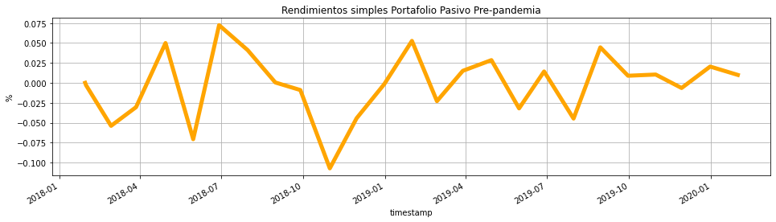

```python
import matplotlib.pyplot as plt
df_pasiva_a['rend'].plot(figsize=(16,4),color='orange', linewidth=5)
plt.ylabel('%')
plt.title('Rendimientos simples Portafolio Pasivo Pre-pandemia')
plt.grid()
```

Con esta gráfica de rendimientos simples podemos ver cómo estos fueron evolucionando a lo largo del tiempo, de los cuales podemos resaltar las siguientes estadísticas de su comportamiento en el periodo prepandemia:

```python
print('\033[1m'+'Rendimiento medio de ' + str(df_pasiva_a['rend'].mean()) + ', un mínimo de '
      + str(df_pasiva_a['rend'].min()) + ' y  un máximo de ' + str(df_pasiva_a['rend'].max()) )
```

```
Rendimiento medio de -0.002252558605475954, un mínimo de -0.10732798263457644 y  un máximo de 0.07239399601425256
```

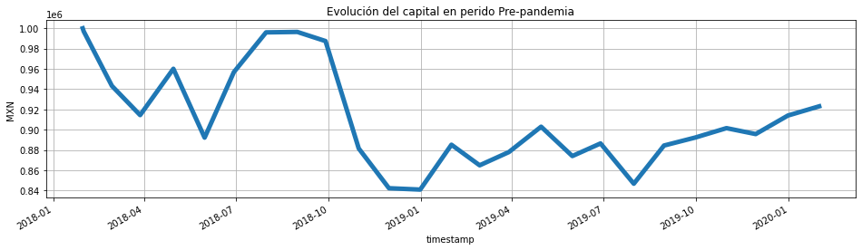

```python
df_pasiva_a['capital'].plot(figsize=(16,4), linewidth=5);
plt.ylabel('MXN')
plt.title('Evolución del capital en perido Pre-pandemia')
plt.grid()
```

Podemos también ver las estadísticas claves en nuestra evolución de capital:

```python
print('\033[1m'+'Capital medio de ' + str(df_pasiva_a['capital'].mean()*100) + ', un mínimo de '
      + str(df_pasiva_a['capital'].min()) + ' y  un máximo de ' + str(df_pasiva_a['capital'].max()) )
```

```
Capital medio de 91371439.0880006, un mínimo de 840893.0749602973 y  un máximo de 1000000.0
```

## - Periodo En-pandemia 28-02-2020 a 28-02-2021

Iniciamos el segundo periodo del 28 de Febrero del 2020 hasta el 28 de Febrero del 2021, recordando que solo ajustaremos nuestro balance al primer mes y veremos cómo evoluciono el capital en este lapso de tiempo, sin hacer rebalanceos, por lo tanto solo pagaremos las comisiones del primer y único ajuste.

### Portafolio:

Mostraremos a continuación nuestras posiciones de acuerdo al "NAFTRAC" en este periodo.

```python
## En-pandemia 28-02-2020 a 28-02-2021
## Tomar solo los valores pre-pandemia
portafolio_pasivo_enpandemia = inv_pasiva_posicion(naftrac_stats, dates[25], capital, comision)
# lapso de inv 31-01-2018 a 31-01-2020
lapso_enpandemia = dates[25:]
portafolio_pasivo_enpandemia.less(10)
```

|  | Ticker | Date | Peso (%) | Close | Acciones | $ Total | Comisión |
| --- | --- | --- | --- | --- | --- | --- | --- |
| 817 | AMXL.MX | 2020-02-28 | 0.1446 | 14.875813 | 9720 | 144592.907066 | 180.741134 |
| 818 | FEMSAUBD.MX | 2020-02-28 | 0.1181 | 153.351105 | 770 | 118080.350647 | 147.600438 |
| 819 | WALMEX.MX | 2020-02-28 | 0.1116 | 54.048767 | 2064 | 111556.655273 | 139.445819 |
| 820 | GFNORTEO.MX | 2020-02-28 | 0.1043 | 103.854584 | 1004 | 104270.002075 | 130.337503 |
| 821 | GMEXICOB.MX | 2020-02-28 | 0.0592 | 42.618095 | 1389 | 59196.534508 | 73.995668 |
| 845 | GCC.MX | 2020-02-28 | 0.0063 | 97.17202 | 64 | 6219.009277 | 7.773762 |
| 846 | CUERVO.MX | 2020-02-28 | 0.0061 | 29.55541 | 206 | 6088.414539 | 7.610518 |
| 847 | LABB.MX | 2020-02-28 | 0.0059 | 19.92 | 296 | 5896.320023 | 7.3704 |
| 848 | RA.MX | 2020-02-28 | 0.0047 | 103.566154 | 45 | 4660.476952 | 5.825596 |
| 849 | ALPEKA.MX | 2020-02-28 | 0.002 | 13.280087 | 150 | 1992.012978 | 2.490016 |

En este DataFrame podemos visualizar las posturas que tomamos por activo en el periodo en-pandemia. Al iniciar nuestro primer portafolio, la columna "Peso (%)" representa el porcentaje del capital invertido por activo, "Close" es nuestro precio de cierre el cuál simulamos comprar el activo, "Acciones" representa nuestra posición por activo, recordando solo se pueden comprar acciones completas, por lo tanto, bajamos el porcentaje al entero más cercano, "$ Total" representa el capital total por acción y "Comisión" son los precios que pagamos por obtener el activo.

### Simulación de la inversión:

Los pasos que seguimos para obtener esta simulación fueron los siguientes:

- Utilizamos las posiciones del portafolio inicial
- Restamos el total de las comisiones a "CASH" en solo el primer mes
- Calculamos su valor a lo largo del tiempo, cada cierre de mes, recordando que no cambiamos el número de estás
- Cada mes sumamos el total del portafolio

```python
# Calculamos los rendimientos del portafolio
df_pasiva_b = pasive_invstmnt_rend(portafolio_pasivo_enpandemia, lapso_enpandemia, capital, naftrac_stats)
df_pasiva_b.less(10)
```

| timestamp | capital | rend | rend_acum |
| --- | --- | --- | --- |
| 2020-02-27 | 1.000000e+06 | 0.000000 | 0.000000 |
| 2020-02-28 | 9.968593e+05 | -0.003141 | -0.003141 |
| 2020-03-31 | 8.403593e+05 | -0.156993 | -0.159641 |
| 2020-04-30 | 8.824896e+05 | 0.050134 | -0.117510 |
| 2020-05-29 | 8.768781e+05 | -0.006359 | -0.123122 |
| 2020-11-30 | 1.033379e+06 | 0.134648 | 0.033379 |
| 2020-12-31 | 1.087415e+06 | 0.052290 | 0.087415 |
| 2021-01-29 | 1.061598e+06 | -0.023741 | 0.061598 |
| 2021-02-26 | 1.103615e+06 | 0.039579 | 0.103615 |
| 2021-03-31 | 1.168068e+06 | 0.058402 | 0.168068 |

En este DataFrame “df_pasiva_b” igual que en el caso anterior, visualizamos los resultados de la inversión mes a mes, pero ahora en el segundo periodo "en-pandemia", repitiendo la manera de hacer los cálculos, el rendimiento “rend se calculó de manera simple ya que por el momento no lo estamos ajustando a ningún modelo. También nuestra columna “rend_acum” que nos muestra el rendimiento acumulado a lo largo del tiempo esta calculada de manera que siempre tomamos el capital inicial de 1’000,000 de referencia, ya que lo que nos interesa es conocer la evolución de este a lo largo del tiempo.

### Visualización del comportamiento de los rendimientos y la evolución del capital a lo largo del tiempo

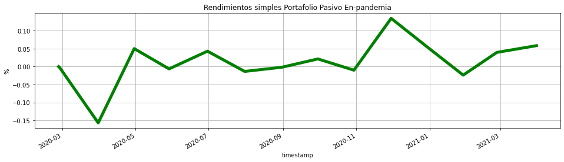

```python
import matplotlib.pyplot as plt
df_pasiva_b['rend'].plot(figsize=(16,4),color='green', linewidth=5)
plt.ylabel('%')
plt.title('Rendimientos simples Portafolio Pasivo En-pandemia')
plt.grid()
```

Con esta gráfica de rendimientos simples podemos observar como fueron evolucionando a lo largo del tiempo en el segundo periodo, de los cuales podemos observar las siguientes estadísticas base:

```python
print('\033[1m'+'Rendimiento medio de ' + str(df_pasiva_b['rend'].mean()) + ', un mínimo de '
      + str(df_pasiva_b['rend'].min()) + ' y  un máximo de ' + str(df_pasiva_b['rend'].max()) )
```

```
Rendimiento medio de 0.0122655875635545, un mínimo de -0.15699299728098048 y  un máximo de 0.13464819300371023
```

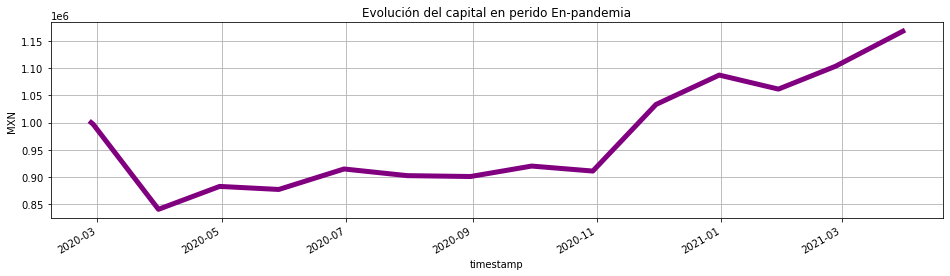

```python
df_pasiva_b['capital'].plot(figsize=(16,4), linewidth=5, color = 'purple');
plt.ylabel('MXN')
plt.title('Evolución del capital en perido En-pandemia')
plt.grid()
```

Podemos también ver las estadísticas claves también en nuestra evolución de capital:

```python
print('\033[1m'+'Capital medio de ' + str(df_pasiva_b['capital'].mean()*100) + ', un mínimo de '
      + str(df_pasiva_b['capital'].min()) + ' y  un máximo de ' + str(df_pasiva_b['capital'].max()) )
```

```
Capital medio de 97326313.03123938, un mínimo de 840359.328901511 y  un máximo de 1168068.0983793554
```

# Inversión activa

Para está parte del laboratorio utilizaremos el mismo escenario, es decir, los activos que tiene el ETF; "NAFTRAC". Pero ahora plantearemos una estrategia de inversión activa, en la cual tomaremos las siguientes consideraciones: - Utilizaremos todo el periodo que va desde 31-01-2018 hasta 28-02-2021 - Solamente usaremos los activos que aparecen en el primer periodo del "NAFTRAC", contabilizaremos como "cash" los activos que se añadan a los periodos siguientes - Se consideran las comisiones a pagar por cada rebalanceo = 0.00125 del valor de la operación (títulos*precio*comisión). - Las operaciones se ejecutan al precio de mercado y se considera un solo precio de compra o de venta para todos los títulos en la operación. - El portafolio rebalancea cada mes de acuerdo a la estrategia de inversión activa. Estrategia de inversión activa: - Disminuir en un 2.5% la posición en títulos de aquellos activos cuyo precio disminuyó un 5% o más. - Aumentar en un 2.5% la posición en títulos de aquellos activos cuyo precio aumentó un 5% o más. - Considera pagar las mismas comisiones por rebalanceo para cada cambio de posición con cada activo según aplique.

### Portafolio inicial

Calculamos nuestro portafolio al iniciar el primer periodo 31-01-2018:

```python
# obtencion del portafolio activo
comision = 0.00125 # (títulos*precio*comisión).
capital = 1000000
portafolio_activo = inv_pasiva_posicion(naftrac_stats, dates[0], capital, comision)
portafolio_activo.less(10)
```

|  | Ticker | Date | Peso (%) | Close | Acciones | $ Total | Comisión |
| --- | --- | --- | --- | --- | --- | --- | --- |
| 0 | AMXL.MX | 2018-01-31 | 0.1331 | 16.014746 | 8311 | 133098.551615 | 166.37319 |
| 1 | FEMSAUBD.MX | 2018-01-31 | 0.1269 | 168.045929 | 755 | 126874.676361 | 158.593345 |
| 2 | GFNORTEO.MX | 2018-01-31 | 0.0951 | 106.891251 | 889 | 95026.321793 | 118.782902 |
| 3 | WALMEX.MX | 2018-01-31 | 0.076 | 43.671349 | 1740 | 75988.146515 | 94.985183 |
| 4 | GMEXICOB.MX | 2018-01-31 | 0.0754 | 54.750771 | 1377 | 75391.811073 | 94.239764 |
| 27 | LALAB.MX | 2018-01-31 | 0.0049 | 26.167149 | 187 | 4893.256786 | 6.116571 |
| 28 | VOLARA.MX | 2018-01-31 | 0.0046 | 15.93 | 288 | 4587.840088 | 5.7348 |
| 29 | LABB.MX | 2018-01-31 | 0.0043 | 20.450001 | 210 | 4294.50016 | 5.368125 |
| 30 | RA.MX | 2018-01-31 | 0.0042 | 103.176376 | 40 | 4127.055054 | 5.158819 |
| 31 | ALPEKA.MX | 2018-01-31 | 0.0032 | 26.630966 | 120 | 3195.715942 | 3.994645 |

Este DataFrame nos muestra como inician nuestras posiciones por activo, precio de compra individual, pesos porcentuales, número de títulos, el total de cada posición y su respectiva comisión al iniciar el portafolio.

### Limpia de datos

El siguiente paso sería quitar los activos que se añadieron después en nuestra lista de precios del "NAFTRAC":

```python
# obtencion del portafolio activo
comision = 0.00125 # (títulos*precio*comisión).
capital = 1000000
portafolio_activo = inv_pasiva_posicion(naftrac_stats, dates[0], capital, comision)

#limpiamos activos que se añaden despues
naftrac_stats_active = limpia_activos(naftrac_stats, portafolio_activo)
naftrac_stats_active.less(10)
```

|  | Ticker | Date | Peso (%) | Close |
| --- | --- | --- | --- | --- |
| 0 | AMXL.MX | 2018-01-31 | 0.1331 | 16.014746 |
| 1 | FEMSAUBD.MX | 2018-01-31 | 0.1269 | 168.045929 |
| 2 | GFNORTEO.MX | 2018-01-31 | 0.0951 | 106.891251 |
| 3 | WALMEX.MX | 2018-01-31 | 0.076 | 43.671349 |
| 4 | GMEXICOB.MX | 2018-01-31 | 0.0754 | 54.750771 |
| 1277 | MEGACPO.MX | 2021-03-31 | 0.0076 | 70.705948 |
| 1282 | LABB.MX | 2021-03-31 | 0.0054 | 20.610001 |
| 1283 | ALSEA.MX | 2021-03-31 | 0.0053 | 30.280001 |
| 1284 | LIVEPOLC-1.MX | 2021-03-31 | 0.0049 | 71.629997 |
| 1285 | RA.MX | 2021-03-31 | 0.0041 | 90.78009 |

Quedan de esta manera nuestros datos iniciales, quitamos los activos que no estaban en el portafolio inicial creando una lista con los “tickers” del primer portafolio, para después utilizarla filtrando el DataFrame “NAFTRAC_STATS”, por el momento solo los eliminamos y haremos el calculo de “CASH” más adelante mes a mes.

### Estrategia de inversión activa

Ya con nuestros datos limpios podemos programar una función que decida comprar y vender de acuerdo con la estrategia de inversión activa:

- Disminuir en un 2.5% la posición en títulos de aquellos activos cuyo precio disminuyó un 5% o más
- Aumentar en un 2.5% la posición en títulos de aquellos activos cuyo precio aumentó un 5% o más

```python
# obtener decisiones de cambios de posición
trading_activo = trading_bot(naftrac_stats_active)
trading_activo.less(10)
```

|  | Ticker | Date | Close | Change | buy | sell |
| --- | --- | --- | --- | --- | --- | --- |
| 44 | AC.MX | 2018-02-28 | 116.401924 | -0.031174 | 0 | 0 |
| 75 | AC.MX | 2018-03-28 | 111.838013 | -0.039208 | 0 | 0 |
| 108 | AC.MX | 2018-04-30 | 114.996269 | 0.02824 | 0 | 0 |
| 139 | AC.MX | 2018-05-31 | 108.361107 | -0.057699 | 0 | 1 |
| 172 | AC.MX | 2018-06-29 | 110.697098 | 0.021557 | 0 | 0 |
| 1118 | WALMEX.MX | 2020-11-30 | 52.810921 | 0.047237 | 0 | 0 |
| 1151 | WALMEX.MX | 2020-12-31 | 55.98 | 0.060008 | 1 | 0 |
| 1185 | WALMEX.MX | 2021-01-29 | 58.349998 | 0.042337 | 0 | 0 |
| 1220 | WALMEX.MX | 2021-02-26 | 59.68 | 0.022794 | 0 | 0 |
| 1254 | WALMEX.MX | 2021-03-31 | 64.470001 | 0.080261 | 1 | 0 |

Podemos observar que nos retorna un DataFrame con las siguientes columnas: - "Change": está representa el cambio porcentual de acuerdo al mes anterior en un mismo activo, para lograrlo eliminamos la fecha inicial de todos nuestros activos ya que se calculó ordenándolo en base al nombre del "ticker" y la "fecha". - "buy": Nos indica la acción a realizar, si arroja "1" significa que el criterio de "aumentar posición" se cumplió, y hay que comprar el porcentaje de la posición. - "sell": de igual forma, si arroja "1" significa que el criterio de "disminuir posición" se cumplió, y hay que vender el porcentaje de la posición.

#### Filtro de solo decisiones:

```python
trading_activo = dec_filter(trading_activo)
trading_activo.less(10)
```

|  | Ticker | Date | Close | Change | buy | sell |
| --- | --- | --- | --- | --- | --- | --- |
| 47 | IENOVA.MX | 2018-02-28 | 89.004959 | -0.079476 | 0 | 1 |
| 58 | GENTERA.MX | 2018-02-28 | 14.374687 | -0.087137 | 0 | 1 |
| 54 | GCARSOA1.MX | 2018-02-28 | 64.412422 | -0.051991 | 0 | 1 |
| 41 | ASURB.MX | 2018-02-28 | 324.345734 | -0.077826 | 0 | 1 |
| 56 | LIVEPOLC-1.MX | 2018-02-28 | 120.362953 | -0.065767 | 0 | 1 |
| 1272 | PE&OLES.MX | 2021-03-31 | 263.630005 | -0.081908 | 0 | 1 |
| 1267 | OMAB.MX | 2021-03-31 | 128.520004 | 0.058998 | 1 | 0 |
| 1256 | GFNORTEO.MX | 2021-03-31 | 112.122818 | 0.09585 | 1 | 0 |
| 1262 | BIMBOA.MX | 2021-03-31 | 41.840744 | 0.091603 | 1 | 0 |
| 1254 | WALMEX.MX | 2021-03-31 | 64.470001 | 0.080261 | 1 | 0 |

Para facilitar nuestros cálculos más adelante filtramos nuestro DataFrame anterior, para solo quedarnos con la lista de los activos sobre los cuales tomaremos alguna acción a lo largo del periodo

# Medidas de Atribución al Desempeño

Para poder hacer una comparación entre una estrategia de inversión pasiva y una estrategia de inversión activa, tomaremos en cuenta medidas de atribución al desempeño básicas. Las cuales, son las siguientes:

- Rendimiento mensual
- Rendimiento mensual acumulado
- Sharpe ratio.

```python
    #---------Medidas de atribucion del desempeño
mad = pd.DataFrame({
            'descripción': ['Rendimiento Promedio Mensual','Rendimiento mensual acumulado','Sharpe Ratio'],
            'inv_activa': ['0','0','0'],
            'inv_pasiva_a': [df_pasiva_a['rend'].mean()*12,df_pasiva_a['rend_acum'].mean()*12,(df_pasiva_a['rend'].mean()*12-0.0429)/df_pasiva_a['rend'].std()],
            'inv_pasiva_b': [df_pasiva_b['rend'].mean()*12,df_pasiva_b['rend_acum'].mean()*12,(df_pasiva_b['rend'].mean()*12-0.0429)/df_pasiva_b['rend'].std()],


        },index=['rend_m', 'rend_c', 'sharpe'])
    df_activa =0
mad
```

|  | descripción | inv_activa | inv_pasiva_a | inv_pasiva_b |
| --- | --- | --- | --- | --- |
| rend_m | Rendimiento Promedio Mensual | 0 | -0.027031 | 0.147187 |
| rend_c | Rendimiento mensual acumulado | 0 | -1.035427 | -0.320842 |
| sharpe | Sharpe Ratio | 0 | -1.705347 | 1.680012 |

# Conclusión

Agregando a las conclusiones que fuimos desarrolando a lo largo del proyecto, es posible observar, con las métricas generadas en la parte de medidas de atribución del desempeño, que podemos evaluar el comportamiento de nuestros diferentes portafolios y compararlos entre ellos, en este laboratorio no alcance a sacar el de inversión activa, sería interesante ver como esa estrategia de designamos tan sencilla impacta los resultados finales. dándonos cuenta si al menos una estrategia sencilla es capaz de sobrepasar los resultados de un portafolio que representa el mercado. También es muy notorio el cambio de las tendencias del mercado en los dos periodos de inversión pasiva, como vimos anteriormente en las gráficas, en el primer periodo hubo una tendencia a la baja, mientras que en el segundo finalizamos con una tendencia alcista.